# 2.High transcript biased gene sets

### Generate lists of mouse genes by number of transcripts.

In the mouse genome, most genes have only one transcript, but some have many more.  
Do sets of genes with high numbers of transcripts produce significant results in GO overrepresentation analysis?

## Number of transcripts per gene

The pre-processed gene info file can be used to plot the distribution of the number of transcripts per gene in the Mus_musculus.GRCm38.94 genome.

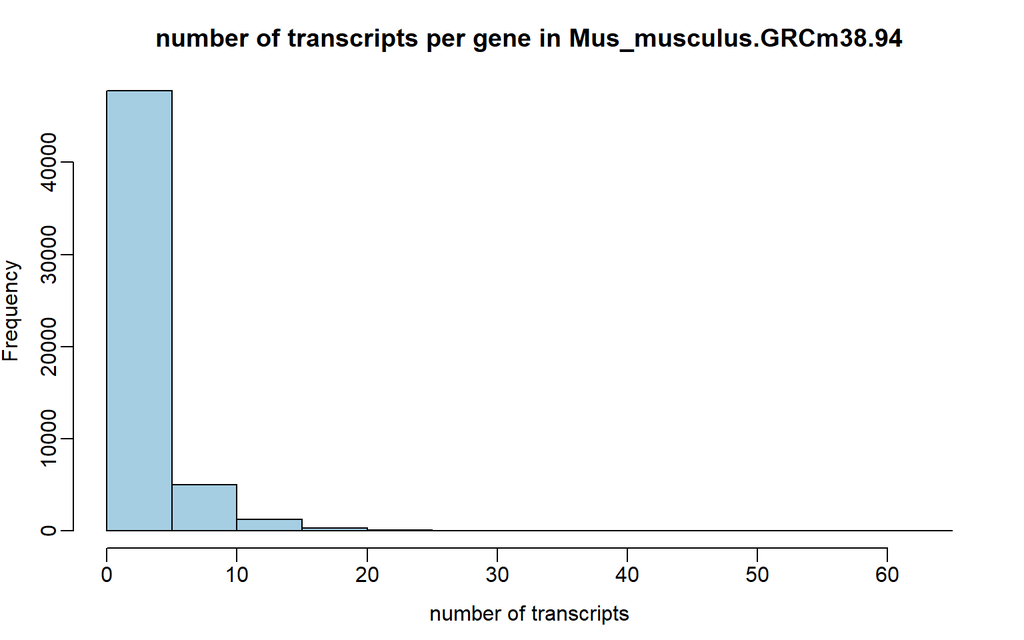

As expected, most genes have very low numbers of transcripts, so we don’t get much information from this plot. We can look at the information in a table format to get actual numbers.

```
    1     2     3     4     5     6     7     8     9    10    11    12
34054  5813  3405  2517  1980  1548  1217   946   711   574   387   314
   13    14    15    16    17    18    19    20    21    22    23    24
  239   180   124    92    67    67    37    39    25    14    15    10
   25    26    27    28    29    30    31    32    33    34    35    36
   17    11     6     7     1     4     7     1     1     3     2     2
   37    38    39    41    46    47    48    58    62
    1     1     1     1     1     1     1     1     1
```

63% of genes only have one transcript. 11% of genes have two transcripts. I’m not interested in these so I’ll replot the data and see how it looks without these values. Above 30 there are only a handful of genes so these can be removed from the plot to see it better.

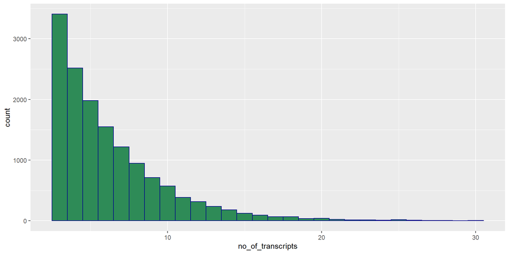

## Thresholds

Originally, I selected arbitrary thresholds of minimum 10, 15 and 20 transcripts per gene. These seemed like reasonable numbers to choose and plenty of functional categories were identified in the overrepresentation tests.

It is not ideal having hardcoded values when it comes to generating further sets of genes. Selecting thresholds dependent on the distribution of the data is a more robust method for applying to different species and future versions of this genome.

|  | transcript_thresholds | probabilities | gene_counts |
| --- | --- | --- | --- |
| 90% | 6 | 0.9 | 6677 |
| 95% | 9 | 0.95 | 2966 |
| 99% | 15 | 0.99 | 561 |

## Generating the biased gene sets

1. Select the subset of genes with high numbers of transcripts.  
2. Randomly select 200 genes.  
3. Repeat 100 times.  
Repeat this for each transcript category.  
The boxplot shows the distribution of transcript numbers for the genes in the biased sets.

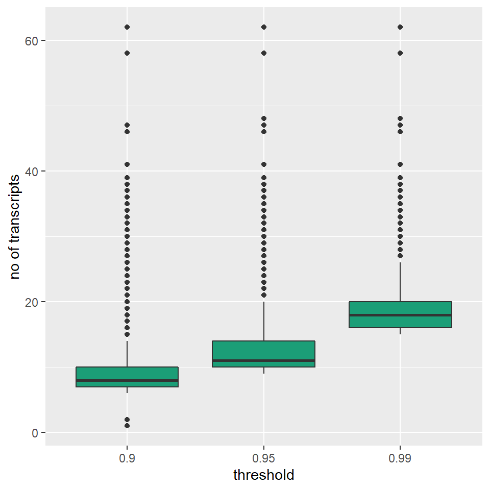

## GO over representation analysis

The biased sets of genes were run through a GO over-representation analysis.

The table shows the number of gene sets that returned significant results from the GO overrepresentation analysis

|  | threshold | results |
| --- | --- | --- |
| 1 | 0.9 | 100 |
| 2 | 0.95 | 100 |
| 3 | 0.99 | 100 |

The bean plot shows the number of significant categories per gene list returned from the GO analysis.

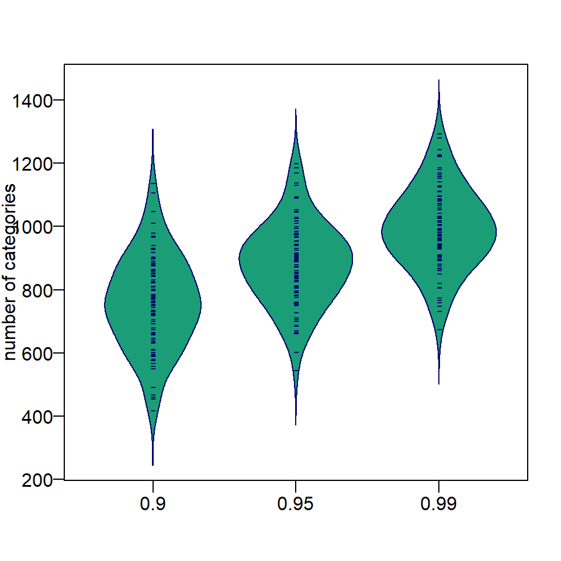

## GO category occurrences

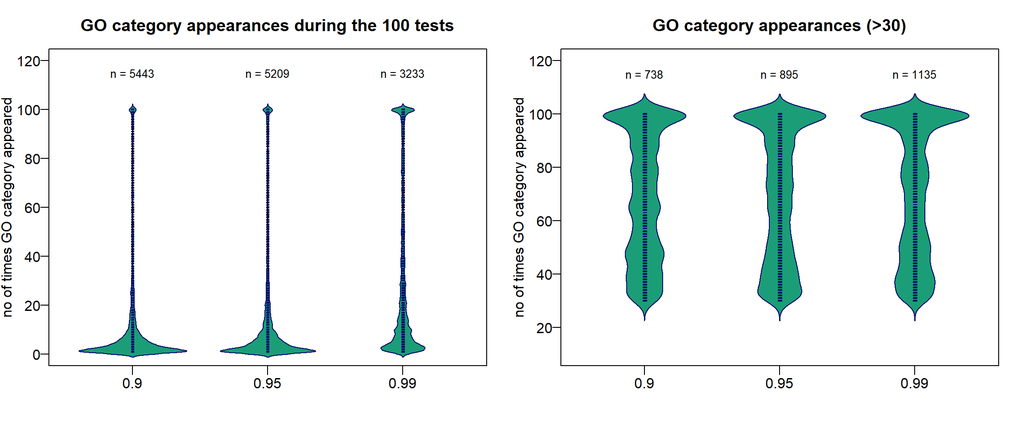

Replot just showing the data for categories that appeared >= 30 times

Now we could do with some stats to pick a cutoff for the number of times a category appears. Let’s just select an arbitrary value for now….

Create a dataset that contains these suspect set of categories

### Deduplicate

There are 789 overlapping categories between 0.99 and 0.95.  
There are 662 overlapping categories between 0.99 and 0.9.  
There are 706 overlapping categories between 0.95 and 0.9.

The duplicate terms will be removed from the more stringent categories.

The number of terms remaining after deduplication

```
 0.9 0.95 0.99
 738  189  340
```

Rename the categories

2019-10-24